# Statistical inference with the GSS data

## Setup

### Load packages

```r
library(ggplot2)
library(dplyr)
library(statsr)
library(plyr)
```

### Load data

```r
load("gss.Rdata")
```

## Part 1: Data

```r
nrow(gss)
```

```
## [1] 57061
```

```r
ncol(gss)
```

```
## [1] 114
```

```r
count(gss$year)
```

```
##       x freq
## 1  1972 1613
## 2  1973 1504
## 3  1974 1484
## 4  1975 1490
## 5  1976 1499
## 6  1977 1530
## 7  1978 1532
## 8  1980 1468
## 9  1982 1860
## 10 1983 1599
## 11 1984 1473
## 12 1985 1534
## 13 1986 1470
## 14 1987 1819
## 15 1988 1481
## 16 1989 1537
## 17 1990 1372
## 18 1991 1517
## 19 1993 1606
## 20 1994 2992
## 21 1996 2904
## 22 1998 2832
## 23 2000 2817
## 24 2002 2765
## 25 2004 2812
## 26 2006 4510
## 27 2008 2023
## 28 2010 2044
## 29 2012 1974
```

From GSS Website: The GSS contains a standard core of demographic, behavioral, and attitudinal questions, plus topics of special interest. Among the topics covered are civil liberties, crime and violence, intergroup tolerance, morality, national spending priorities, psychological well-being, social mobility, and stress and traumatic events.

The given GSS dataset contains 57,061 sample surveys from 1972 to 2012. It has 114 columns or variables. I also checked the frequency per year. They are less than 10% of US population and are random samples based on GSS methodology. Therefore, analysis on GSS samples can apply to general US population.

Since there is no control nor treatment group. Causality analysis does not apply.

## Part 2: Research question

Context In recent years, the political landscape has changed drastically. As the midterm approaches, I find it interesting about historical trends of confidence in the executive branches of the federal government.

Researches By using GSS sample data, I would like to explore whether a person’s race could relate to the confidence one has in the executive branch of federal government.

## Part 3: Exploratory data analysis

```r
gss %>%
  filter(year >= 2008 &
           !is.na(race) &
           !is.na(confed)) %>%
  select(race,confed)  -> gss_races

dim(gss_races)
```

```
## [1] 3985    2
```

A quick summary shows that, if I exclude null values for both variables, my study of past 10 years public confidence in our government will have 3,985 records. Thus I decide to use sample results from year “2008” and later.

Look at dimenionality of variable “race” in our sample set:

```r
table(gss_races$race, useNA = "ifany")
```

```
##
## White Black Other
##  3034   583   368
```

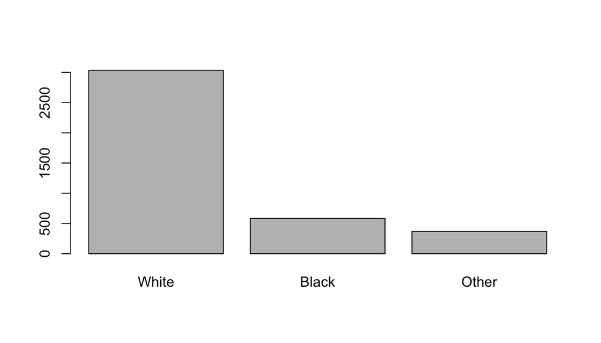

```r
barplot(summary(gss_races$race))
```

Also look at the survey results and sample groups

```r
table(gss_races$race,gss_races$confed)
```

```
##
##         A Great Deal Only Some Hardly Any
##   White          379      1380       1275
##   Black          115       297        171
##   Other           62       208         98
```

In our sample set visualized below, I have surveys from white people, black people and other races. They are obviously all less than 10% of the entire US population. GSS ramdom sampling method also assured me that survey results are independent. Independence can also be assumed cross sample groups.

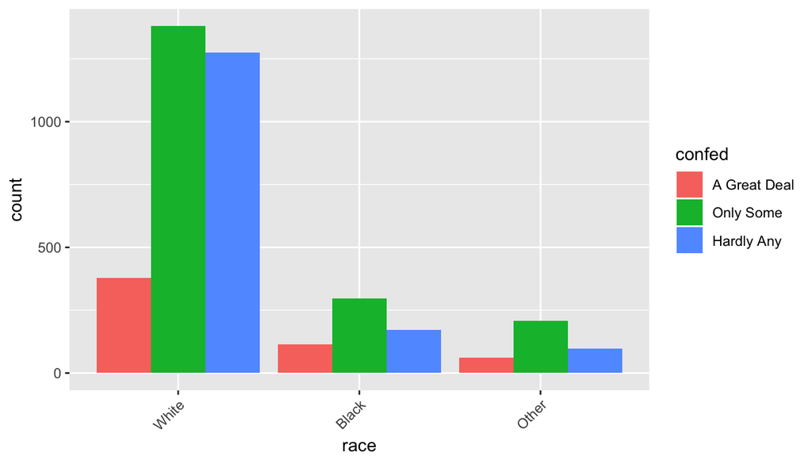

```r
g <- ggplot(data = gss_races, aes(x=race))
g <- g + geom_bar(aes(fill=confed), position = "dodge")
g + theme(axis.text.x = element_text(angle=45,hjust = 1))
```

Examine subgroup and percentage:

```r
(tab <- prop.table(table(gss_races), 1)*100)
```

```
##        confed
## race    A Great Deal Only Some Hardly Any
##   White     12.49176  45.48451   42.02373
##   Black     19.72556  50.94340   29.33105
##   Other     16.84783  56.52174   26.63043
```

My observations include following. In our GSS sample,

1. It is common that people have some confidence in federal government, regardless of their races.
2. White people have the lowest percentage in category of “great deal of confidence”, while black people have the highest percentage.
3. “Other” races have the lowest percentageDistrust of federal government, while white group has the highest disapproval rate in our sample set.

## Part 4: Inference

4.1 Hypothesis Null hypothesis: people’s race is independence of person’s confidence in federal government Alteranative hypothesis: race and faith in government are depedent

4.2 Check conditions Indepedence: GSS sample data is based on random survey methodology. Each record in my study can be considered independent.

Sample: Data candinality indicate that they are drawn from less than 10% of US population

Degree of freedom: “race” has three values while “confed” has three values. Therefore I picked two categorical variables and each has more than 2 values. I can then apply the chi-squared test to test the null hypothesis.

Expected number: shown below, condition is met.

```r
chisq.test(gss_races$race,gss_races$confed)$expected
```

```
##               gss_races$confed
## gss_races$race A Great Deal Only Some Hardly Any
##          White    423.31343 1435.1543  1175.5322
##          Black     81.34203  275.7729   225.8851
##          Other     51.34454  174.0728   142.5827
```

Chi-Square Test of Independence

```r
chisq.test(gss_races$race,gss_races$confed)
```

```
##
##  Pearson's Chi-squared test
##
## data:  gss_races$race and gss_races$confed
## X-squared = 66.836, df = 4, p-value = 1.056e-13
```

The chi-squared statistic is 66.836; p-value for 4 degree of freedom is nearly zero, obviously much lower than the significance level of 0.05. Conversely I rejected my null hypothesis.